# Practical Machine Learning Project

## Machine Learing Model

### Decision tree model

- First I will split the **train_clean** data to train data and test data. Even though the terminology is counfusing, let us do it anyways.

```r
# creating training set and testing test from train_clean data set

in_train <- createDataPartition(
  train_clean$classe, p = 0.70,
  list = FALSE
)

train_set <- train_clean[in_train,]
test_set <- train_clean[-in_train,]
```

Here, I will program a **decesion tree model**,

[figure not shown]

```r
set.seed(1967)
fit_DT <- rpart(classe~., data = train_set, method = "class")
fancyRpartPlot(fit_DT)
```

```r
predict_DT <- predict(fit_DT, newdata = test_set, type="class")
conf_matrix_DT <- confusionMatrix(table(predict_DT, test_set$classe))
conf_matrix_DT
```

```
## Confusion Matrix and Statistics
##
##
## predict_DT    A    B    C    D    E
##          A 1606  170    0    0    0
##          B   22  812   85   55    0
##          C   46  148  926  110   45
##          D    0    9   14  710   83
##          E    0    0    1   89  954
##
## Overall Statistics
##
##                Accuracy : 0.851
##                  95% CI : (0.8416, 0.86)
##     No Information Rate : 0.2845
##     P-Value [Acc > NIR] : < 2.2e-16
##
##                   Kappa : 0.8111
##
##  Mcnemar's Test P-Value : NA
##
## Statistics by Class:
##
##                      Class: A Class: B Class: C Class: D Class: E
## Sensitivity            0.9594   0.7129   0.9025   0.7365   0.8817
## Specificity            0.9596   0.9659   0.9282   0.9785   0.9813
## Pos Pred Value         0.9043   0.8337   0.7263   0.8701   0.9138
## Neg Pred Value         0.9835   0.9334   0.9783   0.9499   0.9736
## Prevalence             0.2845   0.1935   0.1743   0.1638   0.1839
## Detection Rate         0.2729   0.1380   0.1573   0.1206   0.1621
## Detection Prevalence   0.3018   0.1655   0.2167   0.1387   0.1774
## Balanced Accuracy      0.9595   0.8394   0.9154   0.8575   0.9315
```

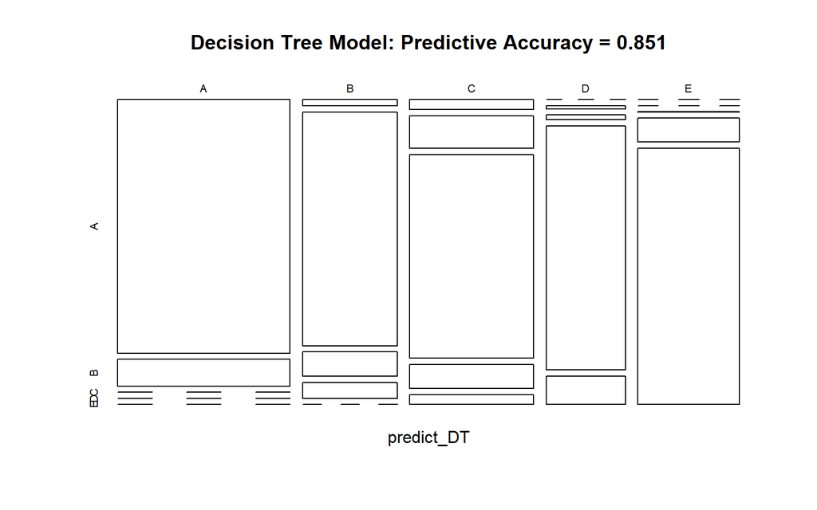

```r
plot(conf_matrix_DT$table, col = conf_matrix_DT$byClass,
     main = paste("Decision Tree Model: Predictive Accuracy =",
                  round(conf_matrix_DT$overall['Accuracy'], 4)))
```

### 10 fold Cross validation Random forest

For this project **Random forest model** is being used. As part of the project, to get accurate prediction **Random forest under 10 fold cross validation** is used. This does bit of some time, be patient.

```r
set.seed(1967)
modFor  <- train(classe~.,
                 data = train_clean,
                 method = "rf",
                 trControl = trainControl(method = "cv", number = 10, verboseIter = FALSE),
                 na.action = na.pass)


modFor
```

[output not shown]

```r
getTrainPerf(modFor)
```

```
##   TrainAccuracy TrainKappa method
## 1      0.998726  0.9983886     rf
```

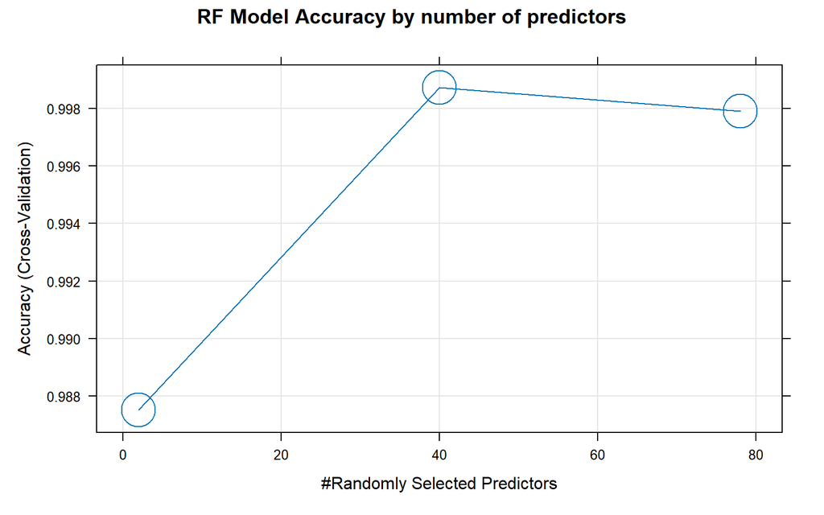

```r
plot(modFor, main="RF Model Accuracy by number of predictors" ,cex=4)
```

Cross validated accuracy is nearly 100%. Out of sample error is less than 0.2%. I see no reason to seek a better model. I anticipate a reduction in accuracy when the data is applied to our testing obervations.

## Prediction and Visualization

```r
prediction_test <- predict(modFor,
                           newdata = test_clean)

prediction_test
```

```
##  [1] B A B A A E D B A A B C B A E E A B B B
## Levels: A B C D E
```